# HW 07 - Smokers in Whichkham

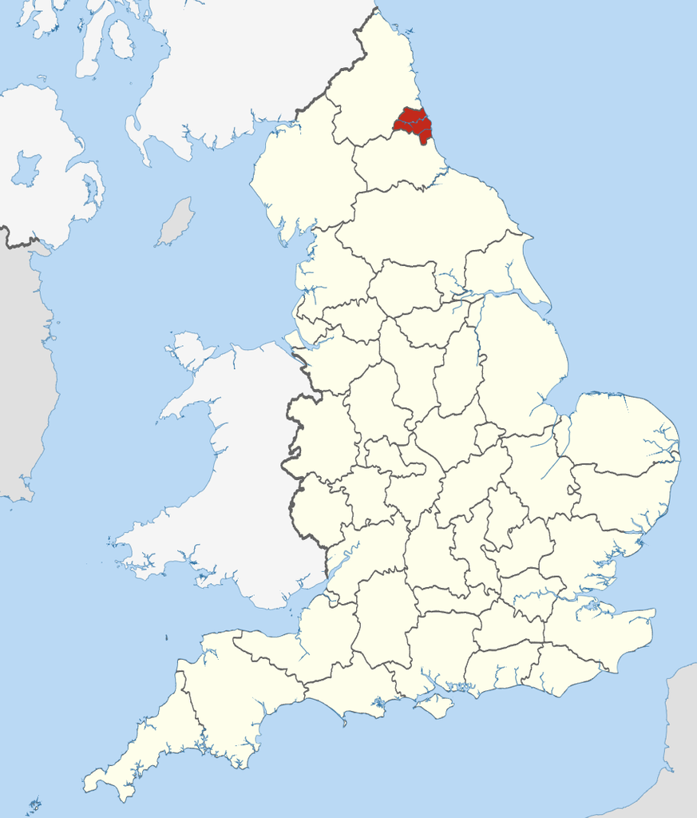

A study of conducted in Whickham, England recorded participants’ age, smoking status at baseline, and then 20 years later recorded their health outcome. In this homework we analyse the relationships between these variables, first two at a time, and then controlling for the third.

# Getting started

Go to Posit Cloud and locate the project folder for “Assignments: Module 7” and open the starter R Markdown document for the HW.

Knit the document to make sure it compiles without errors.

Update the YAML of your R Markdown file with your information.

## Packages

We’ll use the **tidyverse** package for much of the data wrangling and visualization and the data lives in the **mosaicData** package. These packages are already installed for you. You can load them by running the following lines of code:

```r
library(tidyverse)
library(mosaicData)
```

## Data

The dataset we’ll use is called Whickham from the **mosaicData** package. You can find out more about the dataset by inspecting their documentation, which you can access by running `?Whickham` in the Console or using the Help menu in RStudio to search for `Whickham`.

```r
data("Whickham")
```

# Exercises

1. What type of study do you think these data come from: observational or experiment? Why?
2. How many observations are in this dataset? What does each observation represent?
3. How many variables are in this dataset? What type of variable is each?

🧶 👀 💾 *Now is a good time to save and knit your document and confirm the outputs look as you expect them to.*

4. What would you expect the relationship between smoking status and health outcome to be?
5. Describe the relationship between smoking status and health outcomes in terms of (estimated) conditional probabilities. Calculate $P(H)$, $P(H|S)$, and $P(H|\neg S)$. Here is some code to get you started:

```r
Whickham %>%
  count(smoker, outcome)
```

```
  smoker outcome   n
1     No   Alive 502
2     No    Dead 230
3    Yes   Alive 443
4    Yes    Dead 139
```

6. Create a visualization depicting the relationship between smoking status and health outcome. Briefly describe the relationship, and evaluate whether this meets your expectations.
7. Create a new variable called `age_cat` using the following scheme:
- `age <= 44 ~ "18-44"`
- `age > 44 & age <= 64 ~ "45-64"`
- `age > 64 ~ "65+"`
8. Re-create the visualization depicting the relationship between smoking status and health outcome, faceted by `age_cat`. What changed? What might explain this change? Extend the contingency table from earlier by breaking it down by age category and use it to help your narrative.

🧶 👀 💾 *Now is a good time to save and knit your document and confirm the outputs look as you expect them to.*

# Submitting your work

Once you are happy with the final state of your work, change the YAML `output` from `html_output` to `pdf_output.` Now knit the document to produce a final PDF file. Upload the PDF to the Canvas assignment.